# Linear Regression with Continous and Categorical Variables

# Linear Regression:

There are different types of regression. The most common is linear regression. Wikipedia can explain way better: https://en.wikipedia.org/wiki/Linear_regression and https://en.wikipedia.org/wiki/Simple_linear_regression.

Consider this formula from highschool: y=mx+b. Given some data x and y, linear regression will find the slope(m) and y-intercept(b) of a line that minimizes the sum of squared residuals. Residuals in this case are the vertical distance between the data point and the line you are trying to find. Put another way, it will find a line that minimizes the squared distance between each point and the line. The most common method used to find parameters that minimize squared residuals is called ordinary least squares (OLS).

### Load some data:

```r
library(RODBC)
library(ggplot2)
library(data.table)
library(scatterplot3d)

# Get some call centre data
SQL = " SELECT Dept, UDF_text_04, ClientCaptureDate, WordCount, UDF_text_07
FROM CRM.dbo.CM_TRANSCRIPT WITH (NOLOCK)
WHERE UDF_text_07 IN ('General', 'Retention', 'Sales')
AND ClientCaptureDate >= '2021-06-01' "

dbhandle = odbcDriverConnect('driver={SQL Server};Server=sandbox.prd.siriusxm.local;database=CRM;Trusted_Connection=yes')

d = data.table(sqlQuery(dbhandle,SQL))
```

### Visualize the data:

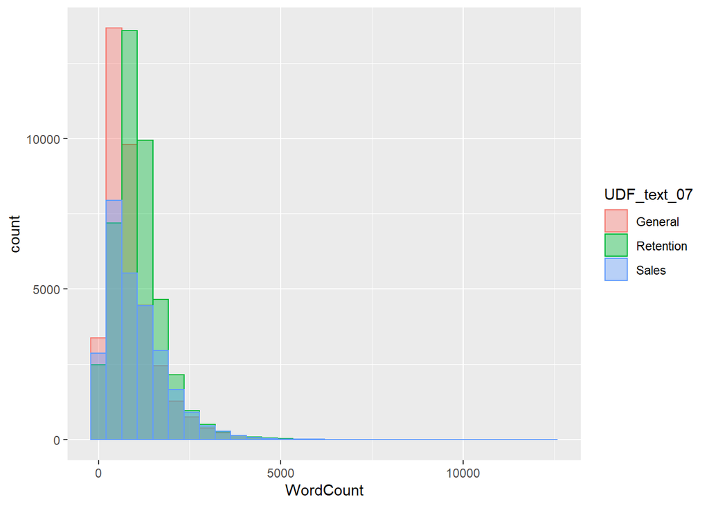

```r
# Histogram of counts
ggplot(d, aes(x=WordCount, fill=UDF_text_07, color=UDF_text_07)) + geom_histogram(alpha=0.4, position='identity')
```

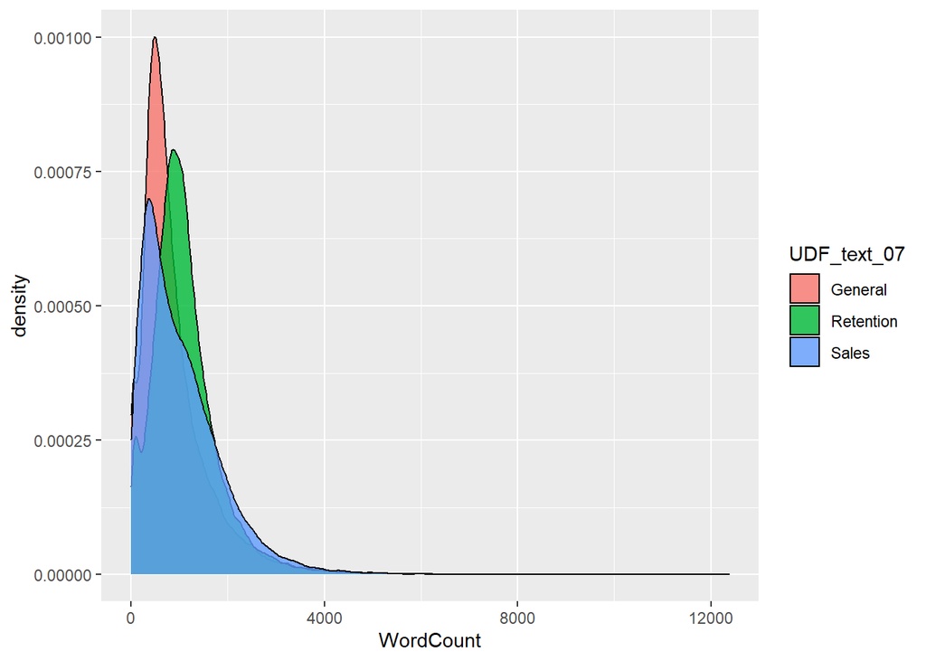

```r
# Density plots which are normalized
ggplot(d, aes(x=WordCount, fill=UDF_text_07)) + geom_density(alpha=0.8)
```

### Look at some summary metrics:

```r
summary(d)
```

```
##         Dept       UDF_text_04    ClientCaptureDate               WordCount
##  Convergys:60184   Cairo :43487   Min.   :2021-06-01 00:00:00   Min.   :    1
##  Sitel    :46272   Manila:46272   1st Qu.:2021-06-04 14:08:00   1st Qu.:  497
##                    Shaw  :16697   Median :2021-06-08 22:24:30   Median :  857
##                                   Mean   :2021-06-08 15:52:42   Mean   : 1018
##                                   3rd Qu.:2021-06-11 19:41:00   3rd Qu.: 1339
##                                   Max.   :2021-06-16 00:02:00   Max.   :12375
##     UDF_text_07
##  General  :36844
##  Retention:42183
##  Sales    :27429
##
##
##
```

# Linear Regression where x and y are continuous:

We will first look at regression where the independent variable (x) and dependent variable (y) are both continous. For this we will group by the call date and take the count of calls.

```r
numCalls = d[, list(NumCalls=length(WordCount)), by = (Date=as.Date(ClientCaptureDate))]
# Order data by date:
numCalls = numCalls[order(numCalls$Date)]
```

Plot:

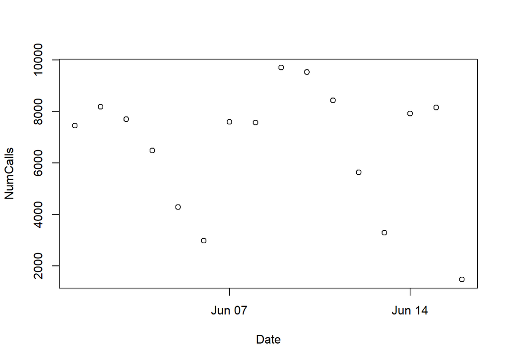

```r
plot(numCalls)
```

### Do some linear regression:

Now let’s try and find the line of best fit. First we will pass the data to lm which can find the slope and intercept parameters for us:

```r
simple_model = lm(NumCalls ~ Date, data = numCalls)
summary(simple_model)
```

```
##
## Call:
## lm(formula = NumCalls ~ Date, data = numCalls)
##
## Residuals:
##     Min      1Q  Median      3Q     Max
## -4388.9 -1168.1   631.7  1898.7  3106.5
##
## Coefficients:
##              Estimate Std. Error t value Pr(>|t|)
## (Intercept) 1996972.7  2511587.8   0.795    0.440
## Date           -105.9      133.7  -0.792    0.441
##
## Residual standard error: 2465 on 14 degrees of freedom
## Multiple R-squared:  0.04293,    Adjusted R-squared:  -0.02543
## F-statistic: 0.628 on 1 and 14 DF,  p-value: 0.4413
```

In the Estimate column beside where it says (Intercept) is the y-intercept and the line below that next to where it says Date is slope. The y-intercept is ridiculously big because the y-intercept is where x=0. x in this case is the Date and date=0 would be the origin date. Normally you’d want to change the origin or scale the date in some way but we will not explore that here.

### Plot the line we just found:

So the lm found our line of best fit and it is stored in the simple_model variable. If we want to plot our model on top of our data, first we use the model to predict y for a range of x’s, and then we plot that.

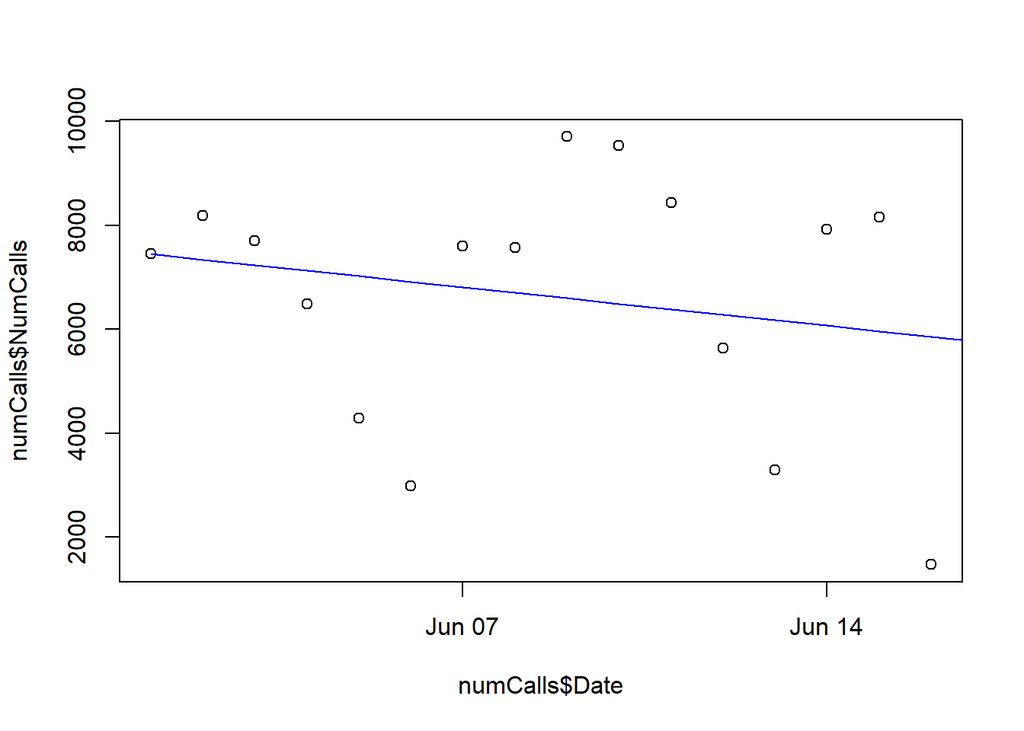

```r
# Predict
newx = seq.Date(from=as.Date('2021-06-01'),to=as.Date('2021-07-01'),by="days")
predy = predict.lm(simple_model, newdata = list(Date = newx))

plot(x=numCalls$Date,y=numCalls$NumCalls)
lines(newx,predy,col='blue')
```

A simpler way to do the above is just to write this:

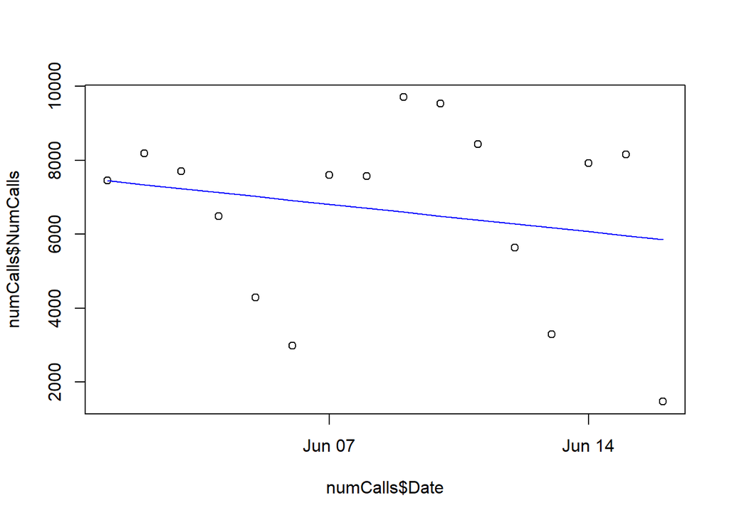

```r
plot(x=numCalls$Date,y=numCalls$NumCalls)
lines(numCalls$Date, predict(simple_model),col='blue')
```

The model is a pretty terrible fit as our data seems to go up and down a lot.

### Trying to get a better fit by transforming your x variable:

It might be better fit by a cubic function:

```r
poly_model = lm(NumCalls ~ poly(Date,3), data = numCalls)
summary(poly_model)
```

```
##
## Call:
## lm(formula = NumCalls ~ poly(Date, 3), data = numCalls)
##
## Residuals:
##     Min      1Q  Median      3Q     Max
## -4041.4 -1542.8   521.2  1372.9  3174.6
##
## Coefficients:
##                Estimate Std. Error t value Pr(>|t|)
## (Intercept)      6653.5      571.4  11.645 6.75e-08 ***
## poly(Date, 3)1  -1953.5     2285.5  -0.855   0.4094
## poly(Date, 3)2  -2158.3     2285.5  -0.944   0.3636
## poly(Date, 3)3  -4211.5     2285.5  -1.843   0.0902 .
## ---
## Signif. codes:  0 '***' 0.001 '**' 0.01 '*' 0.05 '.' 0.1 ' ' 1
##
## Residual standard error: 2285 on 12 degrees of freedom
## Multiple R-squared:  0.2949, Adjusted R-squared:  0.1186
## F-statistic: 1.673 on 3 and 12 DF,  p-value: 0.2255
```

You can see in the regression output that the third term is approaching significance. And visualizing it we can see it’s a better fit:

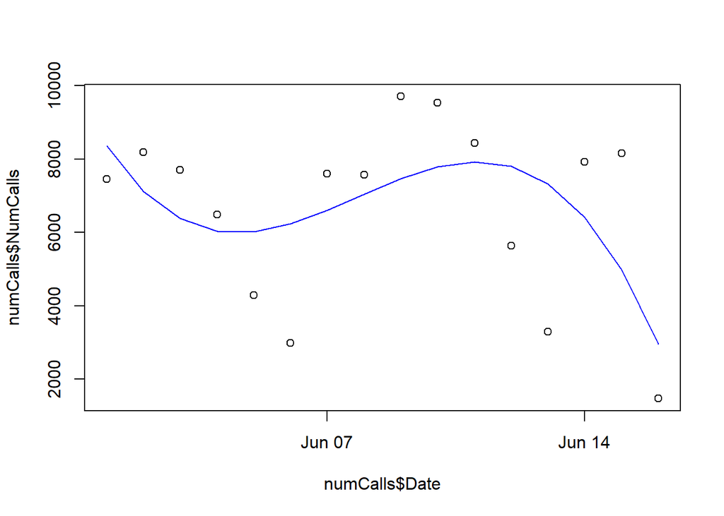

```r
plot(x=numCalls$Date,y=numCalls$NumCalls)
lines(numCalls$Date, predict(poly_model),col='blue')
```

We can do all this in a cooler way using ggplot and geom_smooth.

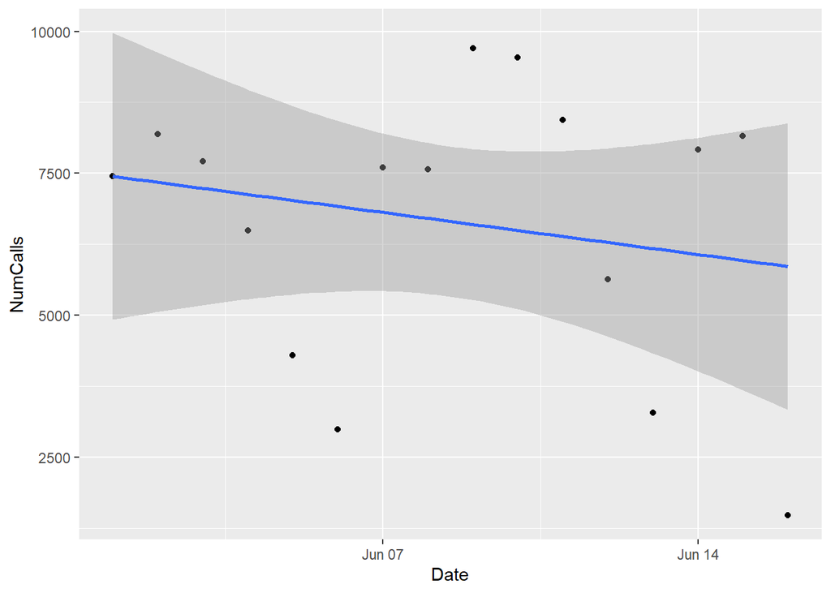

```r
# y ~ x
ggplot(data = numCalls, aes(x=Date,y=NumCalls)) + geom_point() + geom_smooth(method='lm')
```

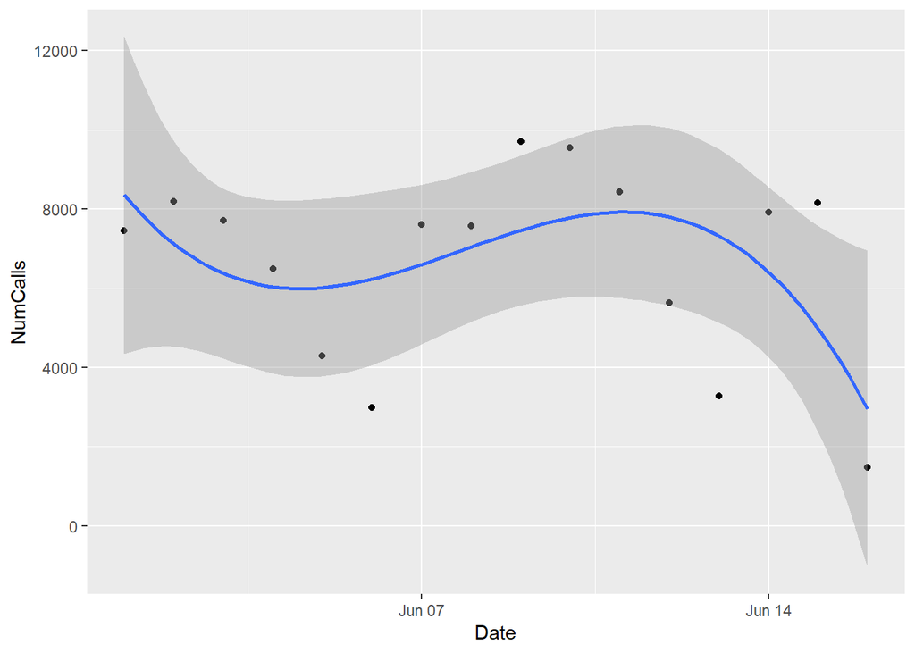

```r
# y ~ x + x^2 + x^3
ggplot(data = numCalls, aes(x=Date,y=NumCalls)) + geom_point() +
  geom_smooth(method="lm",formula = y~poly(x,3))
```

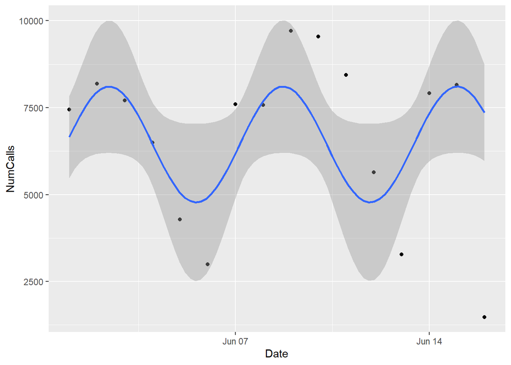

```r
# y ~ cos(x)
ggplot(data = numCalls, aes(x=Date,y=NumCalls)) + geom_point() +
  geom_smooth(method="lm", formula = y~cos(x))
```

# Linear Regression where y is continuous and x is categorical with 2 categories:

A categorical variable can also be called a factor. The number of categories is called levels. So in this case we can also say x is factor with 2 levels.

### Look at just 2 levels:

We will start by just selecting 2 of the call queues:

```r
test_df = d[d$UDF_text_07 == c('Sales','Retention'), c("UDF_text_07","WordCount")]
# Removing unused factor level:
test_df$UDF_text_07 = factor(test_df$UDF_text_07)
```

Let’s look at some summary metrics

```r
test_df[, length(WordCount), by = UDF_text_07]
```

```
##    UDF_text_07    V1
## 1:   Retention 21072
## 2:       Sales 13820
```

```r
test_df[, mean(WordCount), by = UDF_text_07]
```

```
##    UDF_text_07       V1
## 1:   Retention 1111.635
## 2:       Sales 1050.954
```

### Regression time:

```r
model2 = lm(WordCount ~ UDF_text_07, data = test_df)
summary(model2)
```

```
##
## Call:
## lm(formula = WordCount ~ UDF_text_07, data = test_df)
##
## Residuals:
##     Min      1Q  Median      3Q     Max
## -1110.6  -522.6  -137.6   335.4  8787.0
##
## Coefficients:
##                  Estimate Std. Error t value Pr(>|t|)
## (Intercept)      1111.635      5.333 208.446  < 2e-16 ***
## UDF_text_07Sales  -60.681      8.474  -7.161 8.17e-13 ***
## ---
## Signif. codes:  0 '***' 0.001 '**' 0.01 '*' 0.05 '.' 0.1 ' ' 1
##
## Residual standard error: 774.1 on 34890 degrees of freedom
## Multiple R-squared:  0.001468,   Adjusted R-squared:  0.001439
## F-statistic: 51.28 on 1 and 34890 DF,  p-value: 8.169e-13
```

In this case the intercept and slope are much more readable and have meaning. If you notice, the intercept is actually the mean of the Retention group. And if you add the intercept and the slope you get the mean of the Sales group. What kind of sorcery is this?

Let’s think about how a categorical variable fits into y=mx+b. Your x in this case can be two values: Retention and Sales. We can’t really solve our equation if it has words in it. So, what R does internally is one hot encoding. Your x can either be 1 or 0, and that maps back to your categories. Your y-intercept occurs when x is 0, so the y-intercept is the mean of the group which got x = 0. This is because the line of best fit should pass through the mean of each group. The point that is least furthest from all other points in each group is the mean.

Regression can also be used for hypothesis testing. We can see that there are t-values and p-values in the regression output. If the p-value for intercept is significant, then that tells us that the y intercept is significantly different from 0. If the slope is significant, that tells us the slope is significantly different from 0, and in this case it can be interpreted as the means of the two groups being different.

### Visualizing:

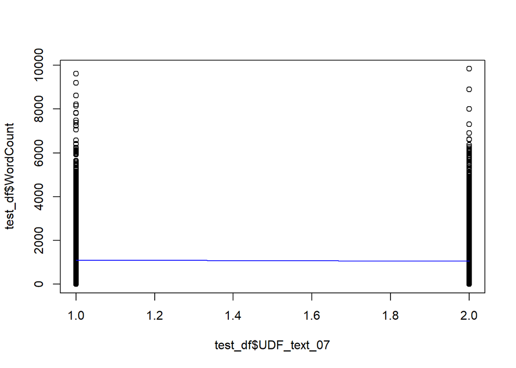

```r
plot.default(x=test_df$UDF_text_07, y=test_df$WordCount)
lines(test_df$UDF_text_07, predict(model2),col='blue')
```

Another way to look at it with boxplots and zoomed in:

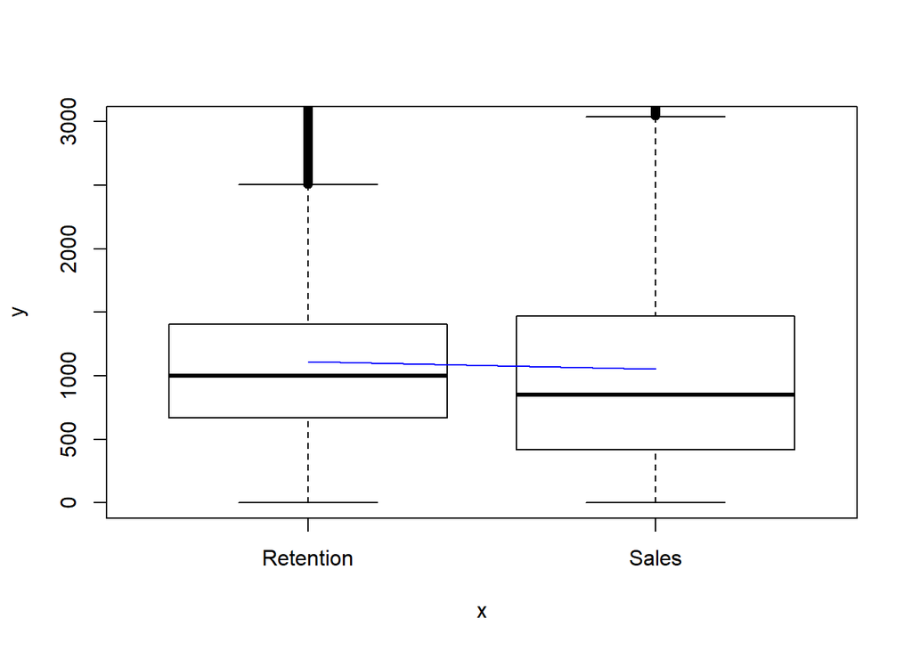

```r
plot(x=test_df$UDF_text_07, y=test_df$WordCount,ylim=c(0,3000))
lines(test_df$UDF_text_07, predict(model2),col='blue')
```

Let’s compare that p-value above to a t-test:

```r
t.test(test_df$WordCount~test_df$UDF_text_07)
```

```
##
##  Welch Two Sample t-test
##
## data:  test_df$WordCount by test_df$UDF_text_07
## t = 6.9239, df = 26149, p-value = 4.495e-12
## alternative hypothesis: true difference in means is not equal to 0
## 95 percent confidence interval:
##  43.50294 77.85845
## sample estimates:
## mean in group Retention     mean in group Sales
##                1111.635                1050.954
```

We can see the absolute t value and also the p-value are pretty close to those observed for the slope.

# Linear Regression where y is continuous and x is categorical with 3 categories:

I hope at this point you are dying to know what happens if you used all 3 call queues in your regression model.

Let’s find out:

```r
model3 = lm(WordCount ~ UDF_text_07, data = d)
summary(model3)
```

```
##
## Call:
## lm(formula = WordCount ~ UDF_text_07, data = d)
##
## Residuals:
##     Min      1Q  Median      3Q     Max
## -1111.1  -493.1  -164.1   301.1 11486.1
##
## Coefficients:
##                      Estimate Std. Error t value Pr(>|t|)
## (Intercept)           888.949      3.982  223.25   <2e-16 ***
## UDF_text_07Retention  223.123      5.450   40.94   <2e-16 ***
## UDF_text_07Sales      157.708      6.095   25.87   <2e-16 ***
## ---
## Signif. codes:  0 '***' 0.001 '**' 0.01 '*' 0.05 '.' 0.1 ' ' 1
##
## Residual standard error: 764.3 on 106453 degrees of freedom
## Multiple R-squared:  0.01597,    Adjusted R-squared:  0.01595
## F-statistic:   864 on 2 and 106453 DF,  p-value: < 2.2e-16
```

Hmm. We only passed one x varible in, but here it looks like we are doing regression with 2 x variables.

Sidenote, if you have multiple x variables, each X get’s its own estimate for slope. These are usually called betas instead of slope. For example if you had 3 x variables, your equation would be y = m1x2 + m2x2 +m3x3 + b, and linear regression would estimate all 3 m.

The reason it looks like we are doing regression on 2 x variables is because we are. In order to one hot encode a factor with 3 levels, you need two columns.

### Visualizing the model and data:

Let’s plot our model and data like we did previously:

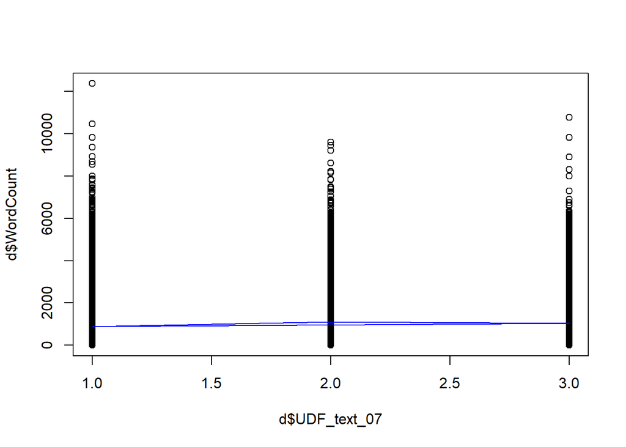

```r
plot.default(x=d$UDF_text_07,y=d$WordCount)
lines(d$UDF_text_07, predict(model3),col='blue')
```

And now let’s zoom in to see what our line looks like:

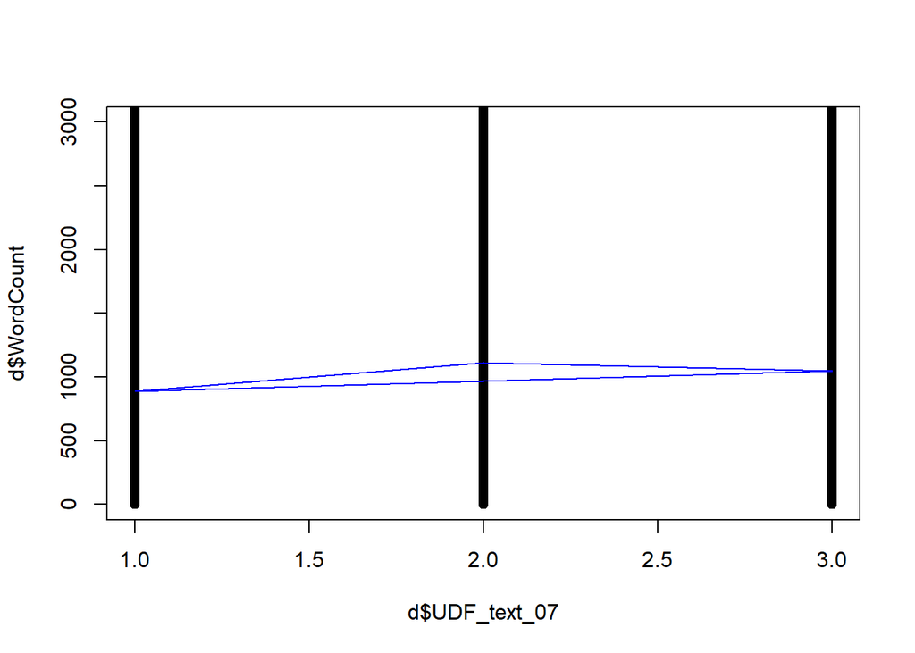

```r
plot.default(x=d$UDF_text_07,y=d$WordCount,ylim = c(0,3000))
lines(d$UDF_text_07, predict(model3),col='blue')
```

Huh? What kind of line is this? How come it’s splitting like that? Did we break it?

Nope, this is actually correct. Remember, we have 2 x variables and a y variable so that means our data is 3 dimensional. It looks broken because we are viewing it in 2D. Let’s see what it looks like in 3D.

### Visualizing linear regression with a factor with 3 levels

First we will manually create the one hot encoding:

```r
# Manually create dummy variables:
d$x1 = ifelse(d$UDF_text_07 == 'Retention',1,0)
d$x2 = ifelse(d$UDF_text_07 == 'Sales',1,0)
```

Now let’s make sure the regression output is exactly the same:

```r
# Double check that this is the same as the model we did before with UDF_text_07
model3 = lm(WordCount ~ x1 + x2, data = d)
summary(model3)
```

```
##
## Call:
## lm(formula = WordCount ~ x1 + x2, data = d)
##
## Residuals:
##     Min      1Q  Median      3Q     Max
## -1111.1  -493.1  -164.1   301.1 11486.1
##
## Coefficients:
##             Estimate Std. Error t value Pr(>|t|)
## (Intercept)  888.949      3.982  223.25   <2e-16 ***
## x1           223.123      5.450   40.94   <2e-16 ***
## x2           157.708      6.095   25.87   <2e-16 ***
## ---
## Signif. codes:  0 '***' 0.001 '**' 0.01 '*' 0.05 '.' 0.1 ' ' 1
##
## Residual standard error: 764.3 on 106453 degrees of freedom
## Multiple R-squared:  0.01597,    Adjusted R-squared:  0.01595
## F-statistic:   864 on 2 and 106453 DF,  p-value: < 2.2e-16
```

Looks the same, awesome. Now let’s graph this:

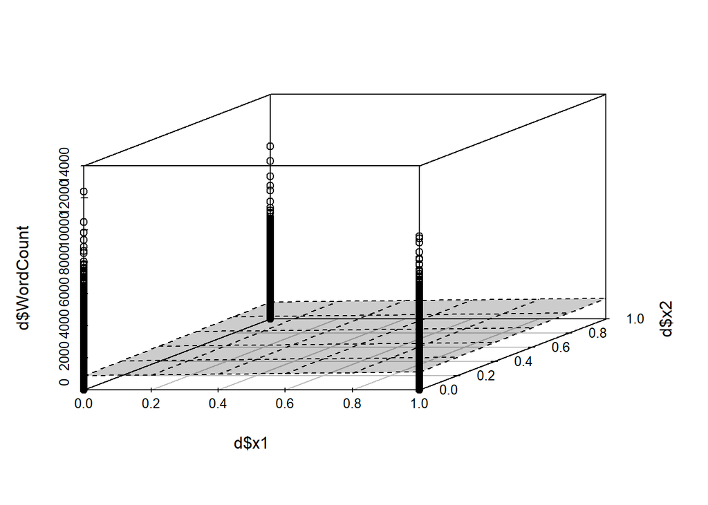

```r
s3d = scatterplot3d(z=d$WordCount, x=d$x1, y=d$x2)
s3d$plane3d(model3,draw_polygon = TRUE)
```

We actually have a regression plane in this case which is the grey thing. Let’s zoom in a bit to see it better:

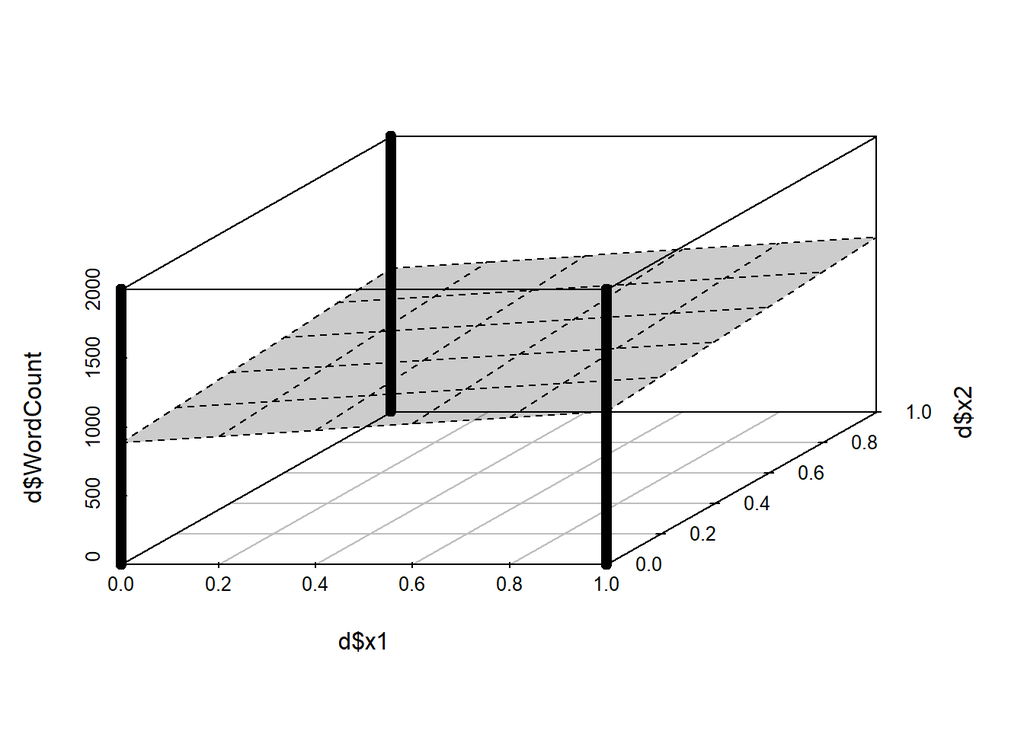

```r
s3d = scatterplot3d(z=d$WordCount, x=d$x1, y=d$x2,zlim=c(0,2000))
s3d$plane3d(model3,draw_polygon = TRUE)
```

If you try to imagine squishing this into 2D, hopefully the lines we saw in the 2D plot start to make sense.

Notes:

http://www.sthda.com/english/wiki/scatterplot3d-3d-graphics-r-software-and-data-visualization

https://stats.stackexchange.com/questions/92065/why-is-polynomial-regression-considered-a-special-case-of-multiple-linear-regres